# Effects of N Addition on AMF Diversity in WI Switchgrass Cropping Systems

```r
master[,colnames(master) %in% names(which(asv_list_sum == 26))][11,] > 0
```

```
##    ASV_17 ASV_49 ASV_86 ASV_89 ASV_92 ASV_95 ASV_98 ASV_109 ASV_122
## 11  FALSE  FALSE   TRUE  FALSE   TRUE   TRUE   TRUE    TRUE    TRUE
##    ASV_127 ASV_130 ASV_131 ASV_146 ASV_155 ASV_160 ASV_161 ASV_163 ASV_170
## 11   FALSE    TRUE    TRUE    TRUE   FALSE    TRUE   FALSE    TRUE    TRUE
##    ASV_177 ASV_186 ASV_189 ASV_190 ASV_191 ASV_196 ASV_204 ASV_217 ASV_226
## 11    TRUE    TRUE    TRUE   FALSE   FALSE    TRUE   FALSE    TRUE   FALSE
##    ASV_235 ASV_236 ASV_270 ASV_271 ASV_275 ASV_291 ASV_294 ASV_299 ASV_305
## 11   FALSE   FALSE    TRUE   FALSE    TRUE   FALSE   FALSE   FALSE    TRUE
##    ASV_306 ASV_318 ASV_319 ASV_320 ASV_339 ASV_349 ASV_368 ASV_371 ASV_372
## 11    TRUE    TRUE   FALSE   FALSE    TRUE   FALSE    TRUE   FALSE   FALSE
##    ASV_388 ASV_392 ASV_393 ASV_394 ASV_402 ASV_406 ASV_426
## 11    TRUE   FALSE   FALSE   FALSE   FALSE    TRUE   FALSE
```

```r
master[,colnames(master) %in% names(which(asv_list_sum == 26))][13,] > 0
```

```
##    ASV_17 ASV_49 ASV_86 ASV_89 ASV_92 ASV_95 ASV_98 ASV_109 ASV_122
## 13   TRUE   TRUE  FALSE   TRUE  FALSE  FALSE  FALSE   FALSE   FALSE
##    ASV_127 ASV_130 ASV_131 ASV_146 ASV_155 ASV_160 ASV_161 ASV_163 ASV_170
## 13    TRUE   FALSE   FALSE   FALSE    TRUE   FALSE    TRUE   FALSE   FALSE
##    ASV_177 ASV_186 ASV_189 ASV_190 ASV_191 ASV_196 ASV_204 ASV_217 ASV_226
## 13   FALSE   FALSE   FALSE    TRUE    TRUE   FALSE    TRUE   FALSE    TRUE
##    ASV_235 ASV_236 ASV_270 ASV_271 ASV_275 ASV_291 ASV_294 ASV_299 ASV_305
## 13    TRUE    TRUE   FALSE    TRUE   FALSE    TRUE    TRUE    TRUE   FALSE
##    ASV_306 ASV_318 ASV_319 ASV_320 ASV_339 ASV_349 ASV_368 ASV_371 ASV_372
## 13   FALSE   FALSE    TRUE    TRUE   FALSE    TRUE   FALSE    TRUE    TRUE
##    ASV_388 ASV_392 ASV_393 ASV_394 ASV_402 ASV_406 ASV_426
## 13   FALSE    TRUE    TRUE    TRUE    TRUE   FALSE    TRUE
```

```r
# 29 - all the ASVs that only occurred in Hancock R4 control
tax[rownames(tax) %in% names(which(asv_list_sum == 29)),]
```

```
##         Kingdom Phylum          Class            Order
## ASV_50  "Fungi" "Glomeromycota" "Glomeromycetes" "Paraglomerales"
## ASV_55  "Fungi" "Glomeromycota" "Glomeromycetes" "Glomerales"
## ASV_64  "Fungi" "Glomeromycota" "Glomeromycetes" "Paraglomerales"
## ASV_74  "Fungi" "Glomeromycota" "Glomeromycetes" "Glomerales"
## ASV_75  "Fungi" "Glomeromycota" "Glomeromycetes" "Glomerales"
## ASV_90  "Fungi" "Glomeromycota" "Glomeromycetes" "Paraglomerales"
## ASV_120 "Fungi" "Glomeromycota" "Glomeromycetes" "Glomerales"
## ASV_139 "Fungi" "Glomeromycota" "Glomeromycetes" "Diversisporales"
## ASV_156 "Fungi" "Glomeromycota" "Glomeromycetes" "Diversisporales"
## ASV_158 "Fungi" "Glomeromycota" "Glomeromycetes" "Diversisporales"
## ASV_179 "Fungi" "Glomeromycota" "Glomeromycetes" "Glomerales"
## ASV_181 "Fungi" "Glomeromycota" "Glomeromycetes" "Diversisporales"
## ASV_197 "Fungi" "Glomeromycota" "Glomeromycetes" "Glomerales"
## ASV_198 "Fungi" "Glomeromycota" "Glomeromycetes" "Diversisporales"
## ASV_212 "Fungi" "Glomeromycota" "Glomeromycetes" "Paraglomerales"
## ASV_238 "Fungi" "Glomeromycota" "Glomeromycetes" "Glomerales"
## ASV_261 "Fungi" "Glomeromycota" "Glomeromycetes" "Glomerales"
## ASV_288 "Fungi" "Glomeromycota" "Glomeromycetes" "Diversisporales"
## ASV_292 "Fungi" "Glomeromycota" "Glomeromycetes" "Glomerales"
## ASV_322 "Fungi" "Glomeromycota" "Glomeromycetes" "Diversisporales"
## ASV_324 "Fungi" "Glomeromycota" "Glomeromycetes" "Glomerales"
## ASV_328 "Fungi" "Glomeromycota" "Glomeromycetes" "Diversisporales"
## ASV_331 "Fungi" "Glomeromycota" "Glomeromycetes" "Glomerales"
## ASV_334 "Fungi" "Glomeromycota" "Glomeromycetes" "Diversisporales"
## ASV_345 "Fungi" "Glomeromycota" "Glomeromycetes" "Glomerales"
## ASV_346 "Fungi" "Glomeromycota" "Glomeromycetes" "Diversisporales"
## ASV_356 "Fungi" "Glomeromycota" "Glomeromycetes" "Glomerales"
## ASV_390 "Fungi" "Glomeromycota" "Glomeromycetes" "Paraglomerales"
## ASV_423 "Fungi" "Glomeromycota" "Glomeromycetes" "Paraglomerales"
##         Family                 Genus
## ASV_50  "Paraglomeraceae"      "Paraglomus"
## ASV_55  "Glomeraceae"          "Dominikia"
## ASV_64  "Paraglomeraceae"      "Paraglomus"
## ASV_74  "Glomeraceae"          "Dominikia"
## ASV_75  "Glomeraceae"          "Dominikia"
## ASV_90  "Paraglomeraceae"      "Paraglomus"
## ASV_120 "Glomeraceae"          "Dominikia"
## ASV_139 "Diversisporaceae"     "Otospora"
## ASV_156 "Diversisporaceae"     "Otospora"
```

[output cut: 35 more lines]

```
## ASV_212 "Paraglomus_brasilianum"
## ASV_238 "Glomus_macrocarpum"
## ASV_261 "Dominikia_indica"
## ASV_288 "Cetraspora_gilmorei"
## ASV_292 "Dominikia_indica"
## ASV_322 "Gigaspora_margarita"
## ASV_324 "Glomus_macrocarpum"
## ASV_328 "Otospora_bareae"
## ASV_331 "Dominikia_indica"
## ASV_334 "Otospora_bareae"
## ASV_345 "Claroideoglomus_claroideum"
## ASV_346 "Cetraspora_gilmorei"
## ASV_356 NA
## ASV_390 "Innospora_majewskii"
## ASV_423 "Paraglomus_brasilianum"
```

```r
master[,colnames(master) %in% names(which(asv_list_sum == 29))]
```

```
##    ASV_50 ASV_55 ASV_64 ASV_74 ASV_75 ASV_90 ASV_120 ASV_139 ASV_156
## 1       0      0      0      0      0      0       0       0       0
## 2       0      0      0      0      0      0       0       0       0
## 3       0      0      0      0      0      0       0       0       0
## 4       0      0      0      0      0      0       0       0       0
## 5       0      0      0      0      0      0       0       0       0
## 6     601    495    432    382    382    290     210     154     125
## 7       0      0      0      0      0      0       0       0       0
## 8       0      0      0      0      0      0       0       0       0
## 9       0      0      0      0      0      0       0       0       0
## 10      0      0      0      0      0      0       0       0       0
## 11      0      0      0      0      0      0       0       0       0
## 12      0      0      0      0      0      0       0       0       0
## 13      0      0      0      0      0      0       0       0       0
## 14      0      0      0      0      0      0       0       0       0
```

[output cut: 77 more lines]

```r
# 34 - all the ASVs that only ocurred in Hancock R2 control
tax[rownames(tax) %in% names(which(asv_list_sum == 34)),]
```

```
##         Kingdom Phylum          Class            Order
## ASV_63  "Fungi" "Glomeromycota" "Glomeromycetes" "Glomerales"
## ASV_106 "Fungi" "Glomeromycota" "Glomeromycetes" "Glomerales"
## ASV_134 "Fungi" "Glomeromycota" "Glomeromycetes" "Glomerales"
## ASV_144 "Fungi" "Glomeromycota" "Glomeromycetes" "Glomerales"
## ASV_145 "Fungi" "Glomeromycota" "Glomeromycetes" "Paraglomerales"
## ASV_178 "Fungi" "Glomeromycota" "Glomeromycetes" "Paraglomerales"
## ASV_203 "Fungi" "Glomeromycota" "Glomeromycetes" "Paraglomerales"
## ASV_205 "Fungi" "Glomeromycota" "Glomeromycetes" "Glomerales"
## ASV_208 "Fungi" "Glomeromycota" "Glomeromycetes" "Glomerales"
## ASV_218 "Fungi" "Glomeromycota" "Glomeromycetes" "Glomerales"
## ASV_241 "Fungi" "Glomeromycota" "Glomeromycetes" "Paraglomerales"
## ASV_260 "Fungi" "Glomeromycota" "Glomeromycetes" "Glomerales"
## ASV_267 "Fungi" "Glomeromycota" "Glomeromycetes" "Paraglomerales"
## ASV_273 "Fungi" "Glomeromycota" "Glomeromycetes" "Glomerales"
## ASV_276 "Fungi" "Glomeromycota" "Glomeromycetes" "Glomerales"
## ASV_283 "Fungi" "Glomeromycota" "Glomeromycetes" "Paraglomerales"
## ASV_284 "Fungi" "Glomeromycota" "Glomeromycetes" "Paraglomerales"
## ASV_293 "Fungi" "Glomeromycota" "Glomeromycetes" "Diversisporales"
## ASV_296 "Fungi" "Glomeromycota" "Glomeromycetes" "Paraglomerales"
## ASV_300 "Fungi" "Glomeromycota" "Glomeromycetes" "Paraglomerales"
## ASV_310 "Fungi" "Glomeromycota" "Glomeromycetes" "Paraglomerales"
## ASV_315 "Fungi" "Glomeromycota" "Glomeromycetes" "Glomerales"
## ASV_316 "Fungi" "Glomeromycota" "Glomeromycetes" "Paraglomerales"
## ASV_330 "Fungi" "Glomeromycota" "Glomeromycetes" "Paraglomerales"
## ASV_333 "Fungi" "Glomeromycota" "Glomeromycetes" "Glomerales"
## ASV_343 "Fungi" "Glomeromycota" "Glomeromycetes" "Paraglomerales"
## ASV_353 "Fungi" "Glomeromycota" "Glomeromycetes" "Glomerales"
## ASV_362 "Fungi" "Glomeromycota" "Glomeromycetes" "Glomerales"
## ASV_363 "Fungi" "Glomeromycota" "Glomeromycetes" "Paraglomerales"
## ASV_375 "Fungi" "Glomeromycota" "Glomeromycetes" "Glomerales"
## ASV_376 "Fungi" "Glomeromycota" "Glomeromycetes" "Glomerales"
## ASV_385 "Fungi" "Glomeromycota" "Glomeromycetes" "Glomerales"
## ASV_412 "Fungi" "Glomeromycota" "Glomeromycetes" "Glomerales"
## ASV_420 "Fungi" "Glomeromycota" "Glomeromycetes" "Paraglomerales"
##         Family            Genus         Species
## ASV_63  "Glomeraceae"     "Dominikia"   "Dominikia_indica"
## ASV_106 "Glomeraceae"     "Dominikia"   "Dominikia_indica"
## ASV_134 "Glomeraceae"     "Dominikia"   "Dominikia_indica"
## ASV_144 "Glomeraceae"     "Dominikia"   "Dominikia_indica"
```

[output cut: 15 more lines]

```
## ASV_300 "Paraglomeraceae" "Paraglomus"  "Paraglomus_brasilianum"
## ASV_310 "Paraglomeraceae" "Paraglomus"  "Paraglomus_brasilianum"
## ASV_315 "Glomeraceae"     "Dominikia"   "Dominikia_indica"
## ASV_316 "Paraglomeraceae" "Paraglomus"  "Paraglomus_brasilianum"
## ASV_330 "Pervetustaceae"  "Pervetustus" "Pervetustus_simplex"
## ASV_333 "Glomeraceae"     "Dominikia"   "Dominikia_indica"
## ASV_343 "Pervetustaceae"  "Pervetustus" "Pervetustus_simplex"
## ASV_353 "Glomeraceae"     "Dominikia"   "Dominikia_indica"
## ASV_362 "Glomeraceae"     "Dominikia"   "Dominikia_indica"
## ASV_363 "Paraglomeraceae" "Paraglomus"  "Paraglomus_brasilianum"
## ASV_375 "Glomeraceae"     "Dominikia"   "Dominikia_indica"
## ASV_376 "Glomeraceae"     "Dominikia"   "Dominikia_indica"
## ASV_385 "Glomeraceae"     "Dominikia"   "Dominikia_indica"
## ASV_412 "Glomeraceae"     "Glomus"      "Glomus_macrocarpum"
## ASV_420 "Pervetustaceae"  "Pervetustus" "Pervetustus_simplex"
```

```r
master[,colnames(master) %in% names(which(asv_list_sum == 34))]
```

```
##    ASV_63 ASV_106 ASV_134 ASV_144 ASV_145 ASV_178 ASV_203 ASV_205 ASV_208
## 1       0       0       0       0       0       0       0       0       0
## 2     434     255     162     139     139      89      66      63      60
## 3       0       0       0       0       0       0       0       0       0
## 4       0       0       0       0       0       0       0       0       0
## 5       0       0       0       0       0       0       0       0       0
## 6       0       0       0       0       0       0       0       0       0
## 7       0       0       0       0       0       0       0       0       0
## 8       0       0       0       0       0       0       0       0       0
## 9       0       0       0       0       0       0       0       0       0
## 10      0       0       0       0       0       0       0       0       0
## 11      0       0       0       0       0       0       0       0       0
## 12      0       0       0       0       0       0       0       0       0
## 13      0       0       0       0       0       0       0       0       0
## 14      0       0       0       0       0       0       0       0       0
```

[output cut: 77 more lines]

Test taxon - check out Rhizophagus intraradices, go to the original genome study and see what the ASVs are, see how they correlate with each other in my study

```r
cor_mat <- cor(master[,28:50], method = "pearson", use = "complete.obs")
round(cor_mat, 2)
```

```
##        ASV_1 ASV_2 ASV_4 ASV_5 ASV_6 ASV_7 ASV_8 ASV_9 ASV_10 ASV_11
## ASV_1   1.00 -0.07 -0.04 -0.07 -0.07 -0.11 -0.08 -0.09  -0.12  -0.07
## ASV_2  -0.07  1.00 -0.09 -0.05 -0.05  0.83 -0.05 -0.06  -0.08  -0.05
## ASV_4  -0.04 -0.09  1.00 -0.09  0.81 -0.14 -0.10 -0.12  -0.15  -0.09
## ASV_5  -0.07 -0.05 -0.09  1.00 -0.05 -0.08 -0.05 -0.06  -0.08  -0.05
## ASV_6  -0.07 -0.05  0.81 -0.05  1.00 -0.08 -0.05 -0.06  -0.08  -0.05
## ASV_7  -0.11  0.83 -0.14 -0.08 -0.08  1.00 -0.09 -0.07   0.10  -0.08
## ASV_8  -0.08 -0.05 -0.10 -0.05 -0.05 -0.09  1.00 -0.07   0.03  -0.05
## ASV_9  -0.09 -0.06 -0.12 -0.06 -0.06 -0.07 -0.07  1.00  -0.11  -0.06
## ASV_10 -0.12 -0.08 -0.15 -0.08 -0.08  0.10  0.03 -0.11   1.00  -0.08
## ASV_11 -0.07 -0.05 -0.09 -0.05 -0.05 -0.08 -0.05 -0.06  -0.08   1.00
## ASV_12 -0.08 -0.06  0.58 -0.06  0.02 -0.10 -0.07 -0.08  -0.11  -0.06
## ASV_13 -0.09 -0.06 -0.11 -0.06 -0.06 -0.10 -0.07 -0.06  -0.08  -0.06
## ASV_14 -0.10 -0.07 -0.12 -0.07 -0.07  0.11  0.08 -0.09   0.83  -0.07
## ASV_15  0.83 -0.05 -0.07 -0.05 -0.05 -0.08 -0.05 -0.06  -0.08  -0.05
## ASV_16  0.95 -0.06 -0.06 -0.06 -0.06 -0.10 -0.07 -0.08  -0.10  -0.06
## ASV_17 -0.07 -0.05 -0.09 -0.05 -0.05 -0.08 -0.05 -0.06  -0.08  -0.05
## ASV_18 -0.09 -0.06 -0.11 -0.06 -0.06 -0.08 -0.07  0.86   0.10  -0.06
## ASV_19 -0.10  0.55 -0.13 -0.07 -0.07  0.43  0.05 -0.10   0.57  -0.07
## ASV_20 -0.07 -0.05 -0.09  1.00 -0.05 -0.08 -0.05 -0.06  -0.08  -0.05
## ASV_21 -0.08 -0.05 -0.10 -0.05 -0.05  0.00 -0.06 -0.03   0.54  -0.05
## ASV_22 -0.07 -0.05 -0.09 -0.05 -0.05  0.00 -0.05  0.35  -0.08  -0.05
## ASV_23 -0.07 -0.05 -0.09 -0.05 -0.05 -0.08  0.99 -0.06  -0.08  -0.05
## ASV_24 -0.09 -0.06 -0.11 -0.06 -0.06 -0.07 -0.07 -0.09  -0.11  -0.06
##        ASV_12 ASV_13 ASV_14 ASV_15 ASV_16 ASV_17 ASV_18 ASV_19 ASV_20
## ASV_1   -0.08  -0.09  -0.10   0.83   0.95  -0.07  -0.09  -0.10  -0.07
## ASV_2   -0.06  -0.06  -0.07  -0.05  -0.06  -0.05  -0.06   0.55  -0.05
## ASV_4    0.58  -0.11  -0.12  -0.07  -0.06  -0.09  -0.11  -0.13  -0.09
## ASV_5   -0.06  -0.06  -0.07  -0.05  -0.06  -0.05  -0.06  -0.07   1.00
## ASV_6    0.02  -0.06  -0.07  -0.05  -0.06  -0.05  -0.06  -0.07  -0.05
## ASV_7   -0.10  -0.10   0.11  -0.08  -0.10  -0.08  -0.08   0.43  -0.08
## ASV_8   -0.07  -0.07   0.08  -0.05  -0.07  -0.05  -0.07   0.05  -0.05
## ASV_9   -0.08  -0.06  -0.09  -0.06  -0.08  -0.06   0.86  -0.10  -0.06
## ASV_10  -0.11  -0.08   0.83  -0.08  -0.10  -0.08   0.10   0.57  -0.08
## ASV_11  -0.06  -0.06  -0.07  -0.05  -0.06  -0.05  -0.06  -0.07  -0.05
## ASV_12   1.00  -0.08  -0.08  -0.06  -0.07  -0.06  -0.08  -0.09  -0.06
## ASV_13  -0.08   1.00  -0.05  -0.06  -0.08   0.21  -0.06  -0.07  -0.06
## ASV_14  -0.08  -0.05   1.00  -0.07  -0.08  -0.07  -0.07   0.73  -0.07
## ASV_15  -0.06  -0.06  -0.07   1.00   0.96  -0.05  -0.06  -0.07  -0.05
## ASV_16  -0.07  -0.08  -0.08   0.96   1.00  -0.06  -0.08  -0.09  -0.06
```

[output cut: 17 more lines]

```
## ASV_10   0.54  -0.08  -0.08  -0.11
## ASV_11  -0.05  -0.05  -0.05  -0.06
## ASV_12  -0.07  -0.06  -0.06  -0.08
## ASV_13  -0.07  -0.06  -0.06   0.02
## ASV_14  -0.02  -0.07  -0.07  -0.09
## ASV_15  -0.05  -0.05  -0.05  -0.06
## ASV_16  -0.07  -0.06  -0.06  -0.08
## ASV_17  -0.05  -0.05  -0.05   0.34
## ASV_18   0.27  -0.06  -0.06  -0.08
## ASV_19  -0.08  -0.07  -0.07  -0.07
## ASV_20  -0.05  -0.05  -0.05  -0.06
## ASV_21   1.00   0.07  -0.05  -0.07
## ASV_22   0.07   1.00  -0.05  -0.06
## ASV_23  -0.05  -0.05   1.00  -0.06
## ASV_24  -0.07  -0.06  -0.06   1.00
```

```r
abs(cor_mat) > .9
```

```
##        ASV_1 ASV_2 ASV_4 ASV_5 ASV_6 ASV_7 ASV_8 ASV_9 ASV_10 ASV_11
## ASV_1   TRUE FALSE FALSE FALSE FALSE FALSE FALSE FALSE  FALSE  FALSE
## ASV_2  FALSE  TRUE FALSE FALSE FALSE FALSE FALSE FALSE  FALSE  FALSE
## ASV_4  FALSE FALSE  TRUE FALSE FALSE FALSE FALSE FALSE  FALSE  FALSE
## ASV_5  FALSE FALSE FALSE  TRUE FALSE FALSE FALSE FALSE  FALSE  FALSE
## ASV_6  FALSE FALSE FALSE FALSE  TRUE FALSE FALSE FALSE  FALSE  FALSE
## ASV_7  FALSE FALSE FALSE FALSE FALSE  TRUE FALSE FALSE  FALSE  FALSE
## ASV_8  FALSE FALSE FALSE FALSE FALSE FALSE  TRUE FALSE  FALSE  FALSE
## ASV_9  FALSE FALSE FALSE FALSE FALSE FALSE FALSE  TRUE  FALSE  FALSE
## ASV_10 FALSE FALSE FALSE FALSE FALSE FALSE FALSE FALSE   TRUE  FALSE
## ASV_11 FALSE FALSE FALSE FALSE FALSE FALSE FALSE FALSE  FALSE   TRUE
## ASV_12 FALSE FALSE FALSE FALSE FALSE FALSE FALSE FALSE  FALSE  FALSE
## ASV_13 FALSE FALSE FALSE FALSE FALSE FALSE FALSE FALSE  FALSE  FALSE
## ASV_14 FALSE FALSE FALSE FALSE FALSE FALSE FALSE FALSE  FALSE  FALSE
## ASV_15 FALSE FALSE FALSE FALSE FALSE FALSE FALSE FALSE  FALSE  FALSE
## ASV_16  TRUE FALSE FALSE FALSE FALSE FALSE FALSE FALSE  FALSE  FALSE
## ASV_17 FALSE FALSE FALSE FALSE FALSE FALSE FALSE FALSE  FALSE  FALSE
## ASV_18 FALSE FALSE FALSE FALSE FALSE FALSE FALSE FALSE  FALSE  FALSE
## ASV_19 FALSE FALSE FALSE FALSE FALSE FALSE FALSE FALSE  FALSE  FALSE
## ASV_20 FALSE FALSE FALSE  TRUE FALSE FALSE FALSE FALSE  FALSE  FALSE
## ASV_21 FALSE FALSE FALSE FALSE FALSE FALSE FALSE FALSE  FALSE  FALSE
## ASV_22 FALSE FALSE FALSE FALSE FALSE FALSE FALSE FALSE  FALSE  FALSE
## ASV_23 FALSE FALSE FALSE FALSE FALSE FALSE  TRUE FALSE  FALSE  FALSE
## ASV_24 FALSE FALSE FALSE FALSE FALSE FALSE FALSE FALSE  FALSE  FALSE
##        ASV_12 ASV_13 ASV_14 ASV_15 ASV_16 ASV_17 ASV_18 ASV_19 ASV_20
## ASV_1   FALSE  FALSE  FALSE  FALSE   TRUE  FALSE  FALSE  FALSE  FALSE
## ASV_2   FALSE  FALSE  FALSE  FALSE  FALSE  FALSE  FALSE  FALSE  FALSE
## ASV_4   FALSE  FALSE  FALSE  FALSE  FALSE  FALSE  FALSE  FALSE  FALSE
## ASV_5   FALSE  FALSE  FALSE  FALSE  FALSE  FALSE  FALSE  FALSE   TRUE
## ASV_6   FALSE  FALSE  FALSE  FALSE  FALSE  FALSE  FALSE  FALSE  FALSE
## ASV_7   FALSE  FALSE  FALSE  FALSE  FALSE  FALSE  FALSE  FALSE  FALSE
## ASV_8   FALSE  FALSE  FALSE  FALSE  FALSE  FALSE  FALSE  FALSE  FALSE
## ASV_9   FALSE  FALSE  FALSE  FALSE  FALSE  FALSE  FALSE  FALSE  FALSE
## ASV_10  FALSE  FALSE  FALSE  FALSE  FALSE  FALSE  FALSE  FALSE  FALSE
## ASV_11  FALSE  FALSE  FALSE  FALSE  FALSE  FALSE  FALSE  FALSE  FALSE
## ASV_12   TRUE  FALSE  FALSE  FALSE  FALSE  FALSE  FALSE  FALSE  FALSE
## ASV_13  FALSE   TRUE  FALSE  FALSE  FALSE  FALSE  FALSE  FALSE  FALSE
## ASV_14  FALSE  FALSE   TRUE  FALSE  FALSE  FALSE  FALSE  FALSE  FALSE
## ASV_15  FALSE  FALSE  FALSE   TRUE   TRUE  FALSE  FALSE  FALSE  FALSE
## ASV_16  FALSE  FALSE  FALSE   TRUE   TRUE  FALSE  FALSE  FALSE  FALSE
```

[output cut: 17 more lines]

```
## ASV_10  FALSE  FALSE  FALSE  FALSE
## ASV_11  FALSE  FALSE  FALSE  FALSE
## ASV_12  FALSE  FALSE  FALSE  FALSE
## ASV_13  FALSE  FALSE  FALSE  FALSE
## ASV_14  FALSE  FALSE  FALSE  FALSE
## ASV_15  FALSE  FALSE  FALSE  FALSE
## ASV_16  FALSE  FALSE  FALSE  FALSE
## ASV_17  FALSE  FALSE  FALSE  FALSE
## ASV_18  FALSE  FALSE  FALSE  FALSE
## ASV_19  FALSE  FALSE  FALSE  FALSE
## ASV_20  FALSE  FALSE  FALSE  FALSE
## ASV_21   TRUE  FALSE  FALSE  FALSE
## ASV_22  FALSE   TRUE  FALSE  FALSE
## ASV_23  FALSE  FALSE   TRUE  FALSE
## ASV_24  FALSE  FALSE  FALSE   TRUE
```

```r
master$ASV_2
```

```
##  [1]    0    0    0    0    0    0    0    0 3187    0    0    0    0    0
## [15]    0    0    0    0    0    0    0    0
```

```r
master$ASV_30
```

```
##  [1]   0   0   0   0   0   0   0   0 963   0   0   0   0   0   0   0   0
## [18]   0   0   0   0   0
```

```r
3187/963
```

```
## [1] 3.30945
```

## Visualization of ASVs

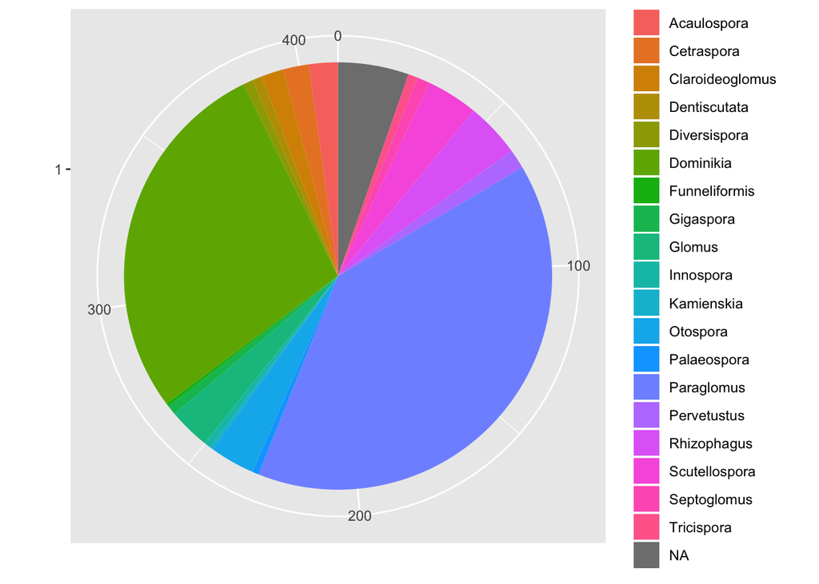

```r
ggplot(as.data.frame(tax), aes(x = factor(1), fill = Genus)) +
  geom_bar(width = 1) +
  xlab("") + ylab("") +
  coord_polar("y")
```

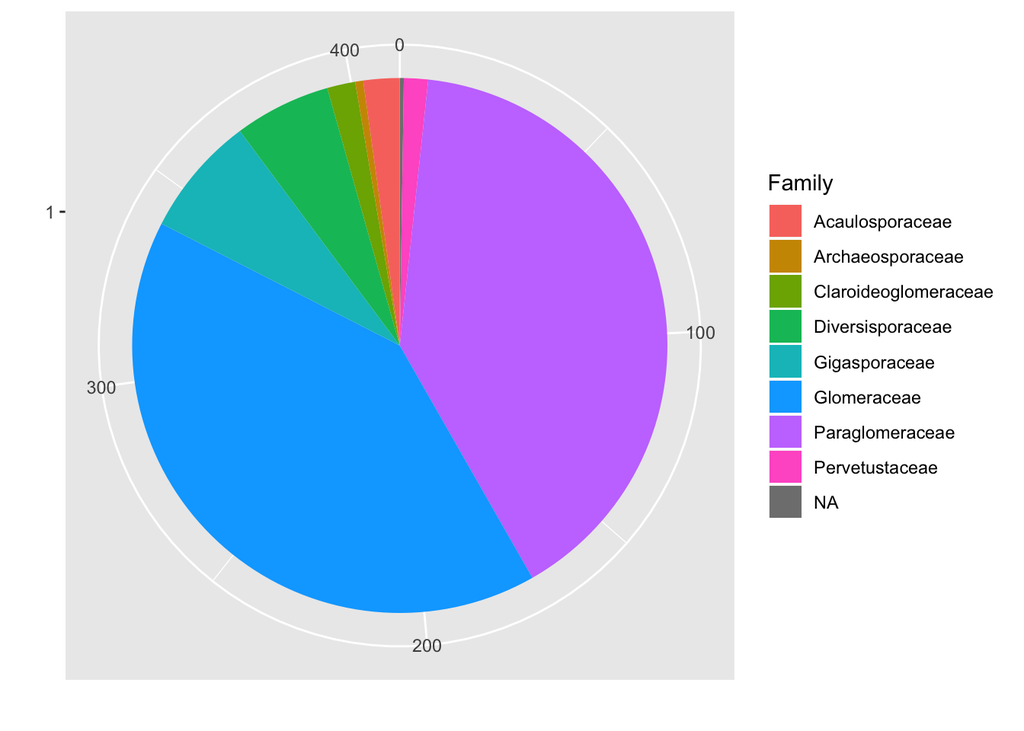

```r
ggplot(as.data.frame(tax), aes(x = factor(1), fill = Family)) +
  geom_bar(width = 1) +
  xlab("") + ylab("") +
  coord_polar("y")
```

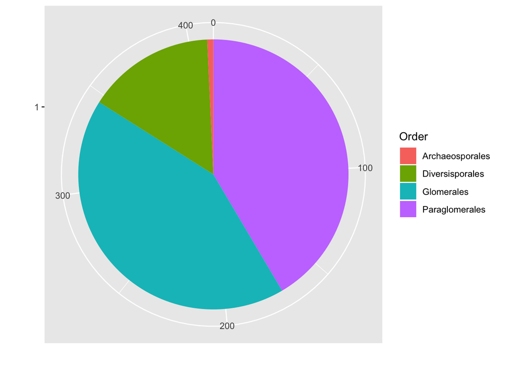

```r
ggplot(as.data.frame(tax), aes(x = factor(1), fill = Order)) +
  geom_bar(width = 1) +
  xlab("") + ylab("") +
  coord_polar("y")
```

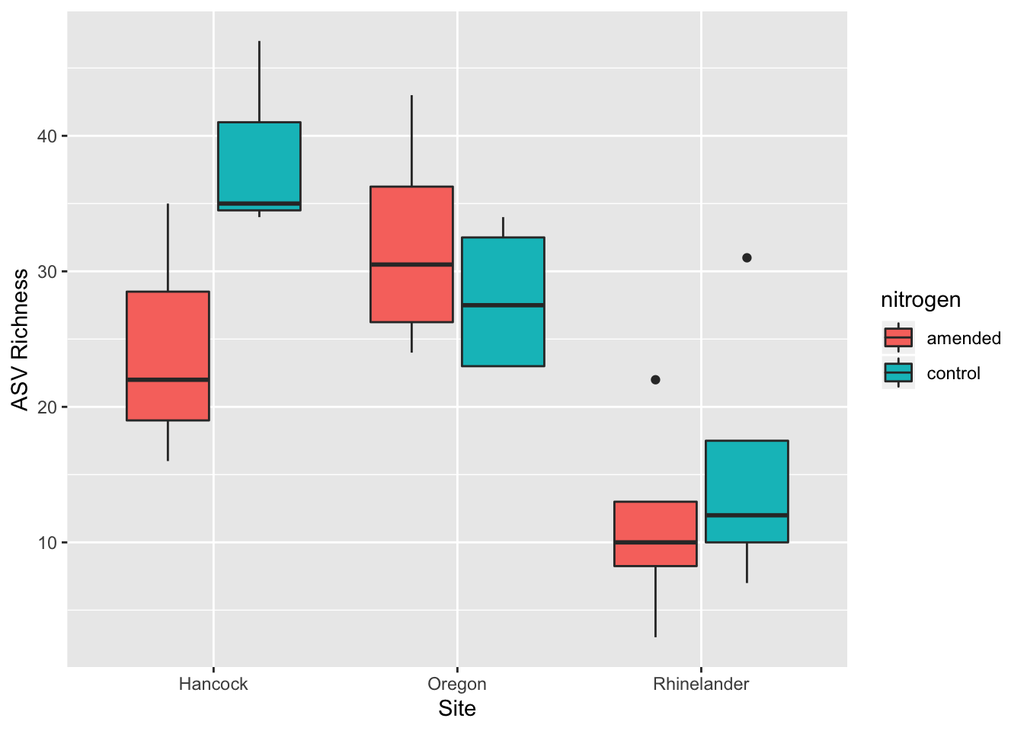

```r
ggplot(master, aes(x = site, y = div_rich, fill = nitrogen)) + geom_boxplot() + labs(y = "ASV Richness", x = "Site")
```

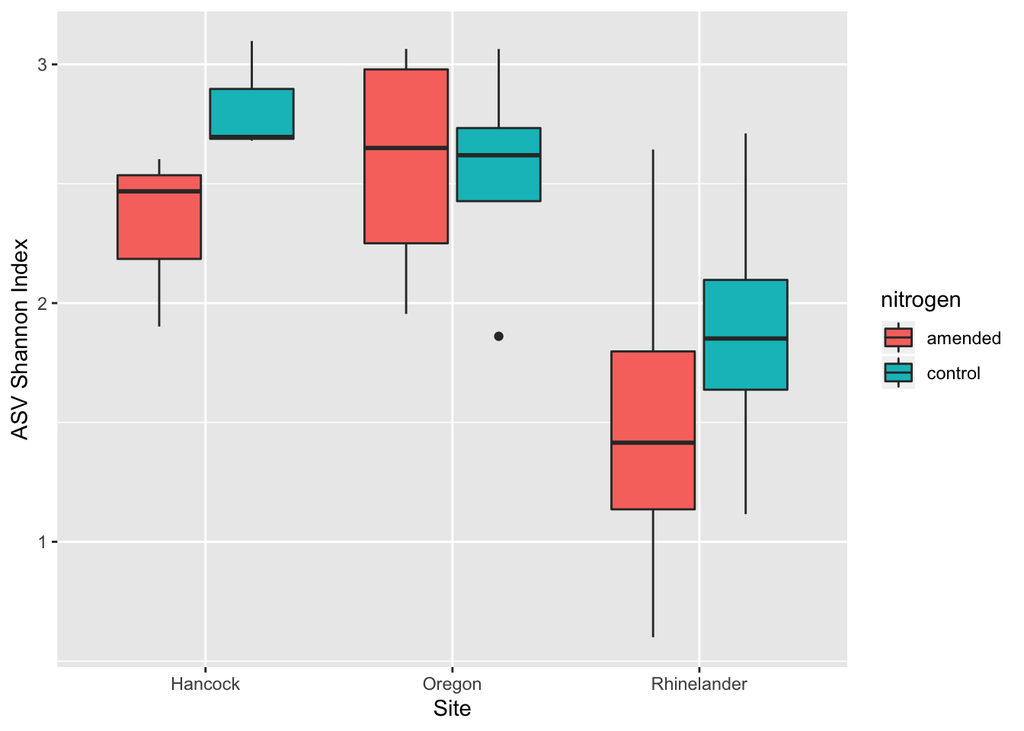

```r
ggplot(master, aes(x = site, y = div_shan, fill = nitrogen)) + geom_boxplot() + labs(y = "ASV Shannon Index", x = "Site")
```

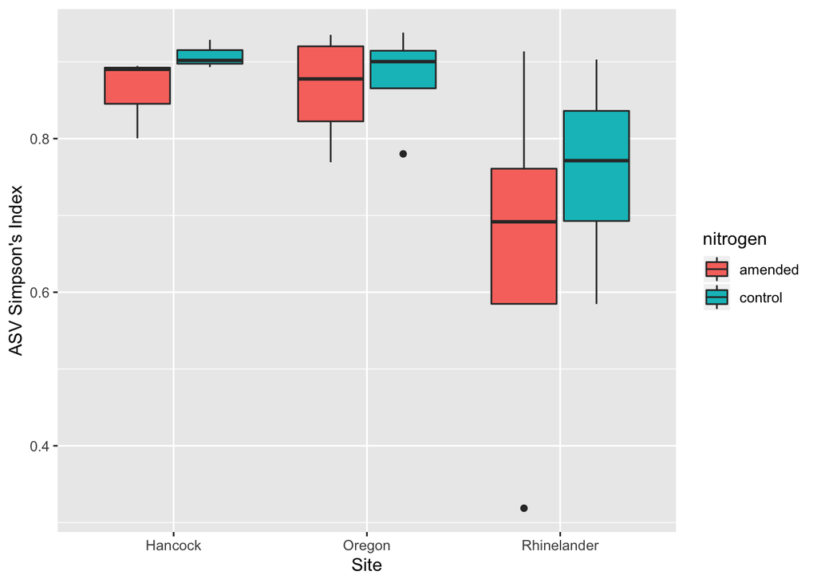

```r
ggplot(master, aes(x = site, y = div_simp, fill = nitrogen)) + geom_boxplot() + labs(y = "ASV Simpson's Index", x = "Site")
```

## Classification and Regression Tree Analysis

```r
rt1 <- rpart(div_rich ~ site + nitrogen + ph + p_ppm + est_cec + per_N + per_C + cn_ratio, data = master, method = "anova")
printcp(rt1)
```

```
##
## Regression tree:
## rpart(formula = div_rich ~ site + nitrogen + ph + p_ppm + est_cec +
##     per_N + per_C + cn_ratio, data = master, method = "anova")
##
## Variables actually used in tree construction:
## [1] p_ppm
##
## Root node error: 3037.1/22 = 138.05
##
## n= 22
##
##        CP nsplit rel error xerror    xstd
## 1 0.50454      0   1.00000 1.1151 0.25216
## 2 0.01000      1   0.49546 1.0009 0.36396
```

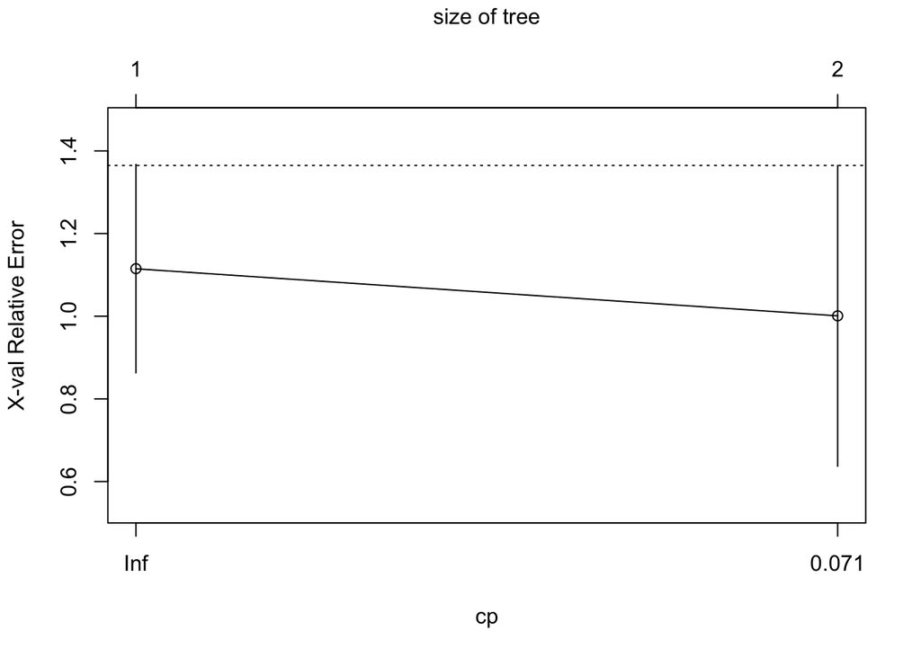

```r
plotcp(rt1)
```

```r
summary(rt1)
```

```
## Call:
## rpart(formula = div_rich ~ site + nitrogen + ph + p_ppm + est_cec +
##     per_N + per_C + cn_ratio, data = master, method = "anova")
##   n= 22
##
##         CP nsplit rel error   xerror     xstd
## 1 0.504536      0  1.000000 1.115083 0.252159
## 2 0.010000      1  0.495464 1.000917 0.363960
##
## Variable importance
##    p_ppm       ph cn_ratio    per_N  est_cec    per_C
##       31       21       17       14       10        7
##
## Node number 1: 22 observations,    complexity param=0.504536
##   mean=24.36364, MSE=138.0496
##   left son=2 (9 obs) right son=3 (13 obs)
##   Primary splits:
##       p_ppm    < 137       to the right, improve=0.5045360, (0 missing)
##       site     splits as  RRL, improve=0.4998209, (0 missing)
##       ph       < 5.85      to the left,  improve=0.3629242, (0 missing)
##       cn_ratio < 11.54374  to the right, improve=0.1625821, (0 missing)
##       per_N    < 0.1971667 to the left,  improve=0.1488785, (0 missing)
##   Surrogate splits:
##       ph       < 5.6       to the left,  agree=0.864, adj=0.667, (0 split)
##       cn_ratio < 11.54374  to the right, agree=0.818, adj=0.556, (0 split)
##       per_N    < 0.1731667 to the left,  agree=0.773, adj=0.444, (0 split)
##       est_cec  < 10.12284  to the left,  agree=0.727, adj=0.333, (0 split)
##       per_C    < 1.398667  to the left,  agree=0.682, adj=0.222, (0 split)
##
## Node number 2: 9 observations
##   mean=14.33333, MSE=69.77778
##
## Node number 3: 13 observations
##   mean=31.30769, MSE=67.44379
```

```r
rt2 <- rpart(div_shan ~ site + nitrogen + ph + p_ppm + est_cec + per_N + per_C + cn_ratio, data = master, method = "anova")
printcp(rt2)
```

```
##
## Regression tree:
## rpart(formula = div_shan ~ site + nitrogen + ph + p_ppm + est_cec +
##     per_N + per_C + cn_ratio, data = master, method = "anova")
##
## Variables actually used in tree construction:
## [1] site
##
## Root node error: 9.8469/22 = 0.44759
##
## n= 22
##
##        CP nsplit rel error  xerror    xstd
## 1 0.38784      0   1.00000 1.11164 0.31416
## 2 0.01000      1   0.61216 0.75254 0.18960
```

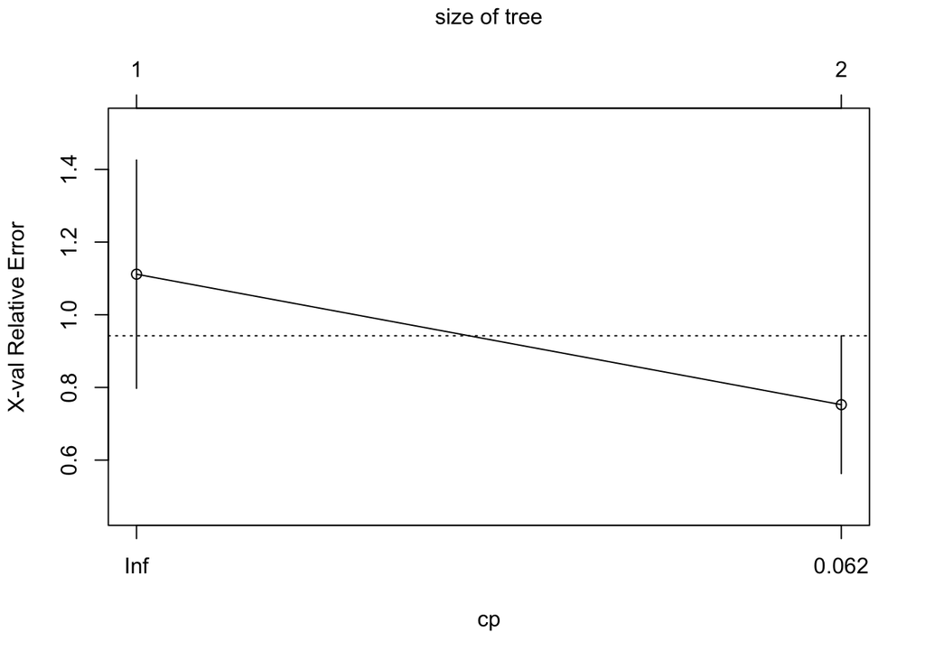

```r
plotcp(rt2)
```

```r
summary(rt2)
```

```
## Call:
## rpart(formula = div_shan ~ site + nitrogen + ph + p_ppm + est_cec +
##     per_N + per_C + cn_ratio, data = master, method = "anova")
##   n= 22
##
##          CP nsplit rel error    xerror      xstd
## 1 0.3878439      0 1.0000000 1.1116374 0.3141592
## 2 0.0100000      1 0.6121561 0.7525402 0.1895977
##
## Variable importance
##    p_ppm     site       ph cn_ratio    per_N    per_C
##       25       25       19       16        9        6
##
## Node number 1: 22 observations,    complexity param=0.3878439
##   mean=2.251628, MSE=0.447586
##   left son=2 (8 obs) right son=3 (14 obs)
##   Primary splits:
##       site    splits as  RRL, improve=0.3878439, (0 missing)
##       p_ppm   < 184.75    to the right, improve=0.3878439, (0 missing)
##       ph      < 5.85      to the left,  improve=0.3324469, (0 missing)
##       per_N   < 0.1971667 to the left,  improve=0.1742168, (0 missing)
##       est_cec < 11.2537   to the left,  improve=0.1198265, (0 missing)
##   Surrogate splits:
##       p_ppm    < 184.75    to the right, agree=1.000, adj=1.000, (0 split)
##       ph       < 5.6       to the left,  agree=0.909, adj=0.750, (0 split)
##       cn_ratio < 11.54374  to the right, agree=0.864, adj=0.625, (0 split)
##       per_N    < 0.1468333 to the left,  agree=0.773, adj=0.375, (0 split)
##       per_C    < 1.398667  to the left,  agree=0.727, adj=0.250, (0 split)
##
## Node number 2: 8 observations
##   mean=1.700457, MSE=0.4617119
##
## Node number 3: 14 observations
##   mean=2.566582, MSE=0.1667243
```

```r
rt3 <- rpart(div_simp ~ site + nitrogen + ph + p_ppm + est_cec + per_N + per_C + cn_ratio, data = master, method = "anova")
printcp(rt3)
```

```
##
## Regression tree:
## rpart(formula = div_simp ~ site + nitrogen + ph + p_ppm + est_cec +
##     per_N + per_C + cn_ratio, data = master, method = "anova")
##
## Variables actually used in tree construction:
## [1] p_ppm
##
## Root node error: 0.45225/22 = 0.020557
##
## n= 22
##
##        CP nsplit rel error  xerror    xstd
## 1 0.33278      0   1.00000 1.11046 0.56862
## 2 0.01000      1   0.66722 0.93316 0.43406
```

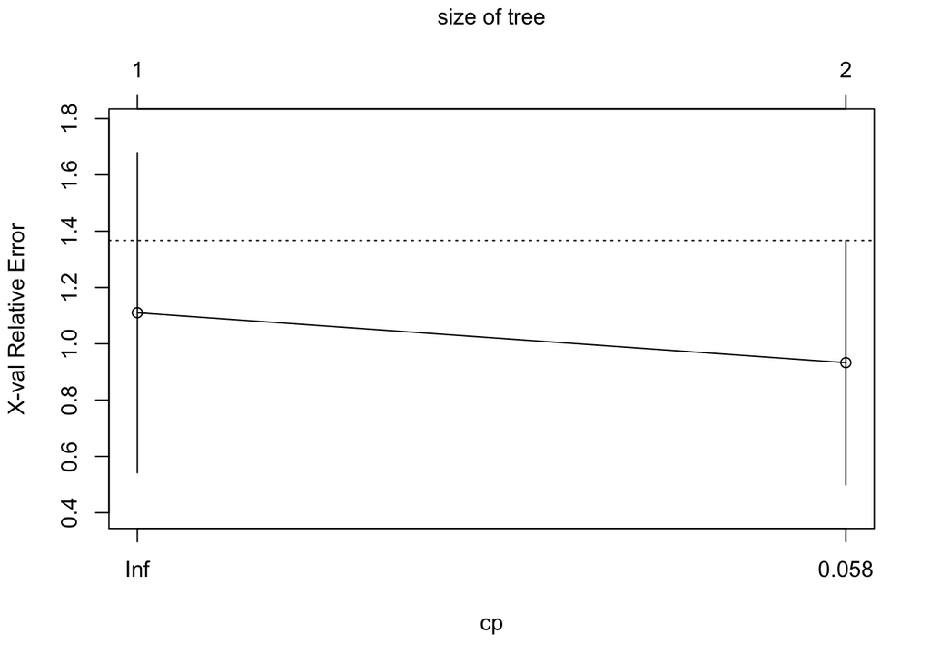

```r
plotcp(rt3)
```

```r
summary(rt3)
```

```
## Call:
## rpart(formula = div_simp ~ site + nitrogen + ph + p_ppm + est_cec +
##     per_N + per_C + cn_ratio, data = master, method = "anova")
##   n= 22
##
##          CP nsplit rel error    xerror      xstd
## 1 0.3327765      0 1.0000000 1.1104572 0.5686203
## 2 0.0100000      1 0.6672235 0.9331621 0.4340605
##
## Variable importance
##    p_ppm       ph cn_ratio    per_N    per_C  est_cec
##       32       24       20       12        8        4
##
## Node number 1: 22 observations,    complexity param=0.3327765
##   mean=0.8151429, MSE=0.02055699
##   left son=2 (8 obs) right son=3 (14 obs)
##   Primary splits:
##       p_ppm    < 184.75    to the right, improve=0.3327765, (0 missing)
##       site     splits as  RRL, improve=0.3327765, (0 missing)
##       ph       < 5.85      to the left,  improve=0.3232500, (0 missing)
##       cn_ratio < 11.54374  to the right, improve=0.1359747, (0 missing)
##       per_N    < 0.1468333 to the left,  improve=0.1178267, (0 missing)
##   Surrogate splits:
##       ph       < 5.6       to the left,  agree=0.909, adj=0.750, (0 split)
##       cn_ratio < 11.54374  to the right, agree=0.864, adj=0.625, (0 split)
##       per_N    < 0.1468333 to the left,  agree=0.773, adj=0.375, (0 split)
##       per_C    < 1.398667  to the left,  agree=0.727, adj=0.250, (0 split)
##       est_cec  < 10.12284  to the left,  agree=0.682, adj=0.125, (0 split)
##
## Node number 2: 8 observations
##   mean=0.7057283, MSE=0.03247351
##
## Node number 3: 14 observations
##   mean=0.8776655, MSE=0.002997591
```

```r
rt4 <- rpart(yield ~ site + nitrogen + div_rich + div_shan + div_simp + ph + p_ppm + est_cec + per_N + per_C + cn_ratio, data = master, method = "anova")
printcp(rt4)
```

```
##
## Regression tree:
## rpart(formula = yield ~ site + nitrogen + div_rich + div_shan +
##     div_simp + ph + p_ppm + est_cec + per_N + per_C + cn_ratio,
##     data = master, method = "anova")
##
## Variables actually used in tree construction:
## [1] per_N
##
## Root node error: 346.16/22 = 15.734
##
## n= 22
##
##        CP nsplit rel error  xerror    xstd
## 1 0.90441      0  1.000000 1.14232 0.16879
## 2 0.01000      1  0.095592 0.43361 0.14005
```

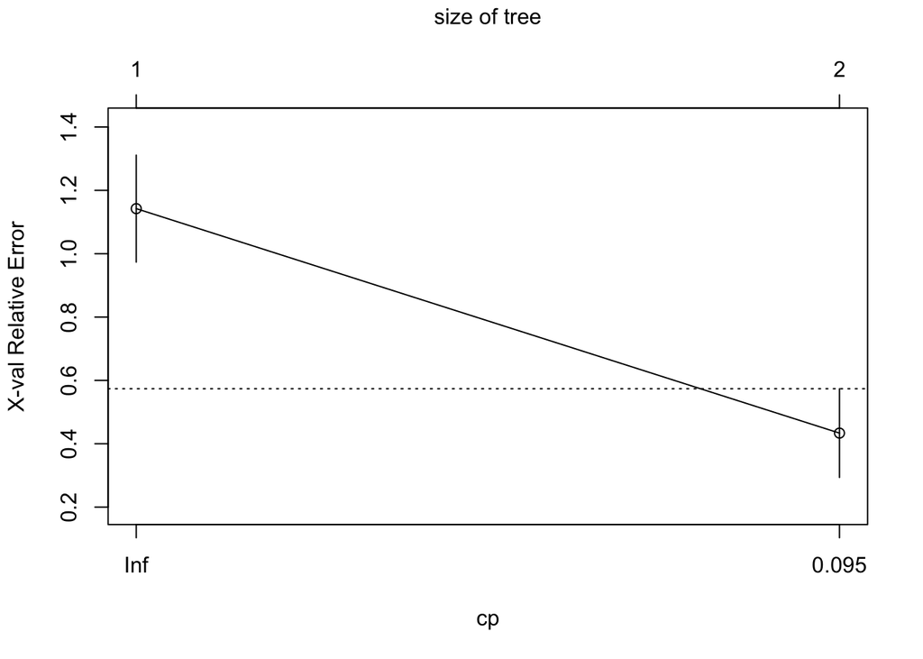

```r
plotcp(rt4)
```

```r
summary(rt4)
```

```
## Call:
## rpart(formula = yield ~ site + nitrogen + div_rich + div_shan +
##     div_simp + ph + p_ppm + est_cec + per_N + per_C + cn_ratio,
##     data = master, method = "anova")
##   n= 22
##
##          CP nsplit  rel error    xerror      xstd
## 1 0.9044081      0 1.00000000 1.1423242 0.1687855
## 2 0.0100000      1 0.09559189 0.4336119 0.1400509
##
## Variable importance
##    p_ppm    per_N cn_ratio  est_cec    per_C div_rich
##       21       21       18       18       13        8
##
## Node number 1: 22 observations,    complexity param=0.9044081
##   mean=5.322388, MSE=15.73432
##   left son=2 (14 obs) right son=3 (8 obs)
##   Primary splits:
##       per_N    < 0.1731667 to the left,  improve=0.9044081, (0 missing)
##       site     splits as  LRL, improve=0.9044081, (0 missing)
##       p_ppm    < 27.25     to the right, improve=0.9044081, (0 missing)
##       cn_ratio < 9.472765  to the right, improve=0.8008650, (0 missing)
##       est_cec  < 10.84605  to the left,  improve=0.7747178, (0 missing)
##   Surrogate splits:
##       p_ppm    < 27.25     to the right, agree=1.000, adj=1.000, (0 split)
##       est_cec  < 10.84605  to the left,  agree=0.955, adj=0.875, (0 split)
##       cn_ratio < 8.415609  to the right, agree=0.955, adj=0.875, (0 split)
##       per_C    < 1.437667  to the left,  agree=0.864, adj=0.625, (0 split)
##       div_rich < 22.5      to the left,  agree=0.773, adj=0.375, (0 split)
##
## Node number 2: 14 observations
##   mean=2.470797, MSE=1.949461
##
## Node number 3: 8 observations
##   mean=10.31267, MSE=0.7246457
```

## Conditional Inference Trees

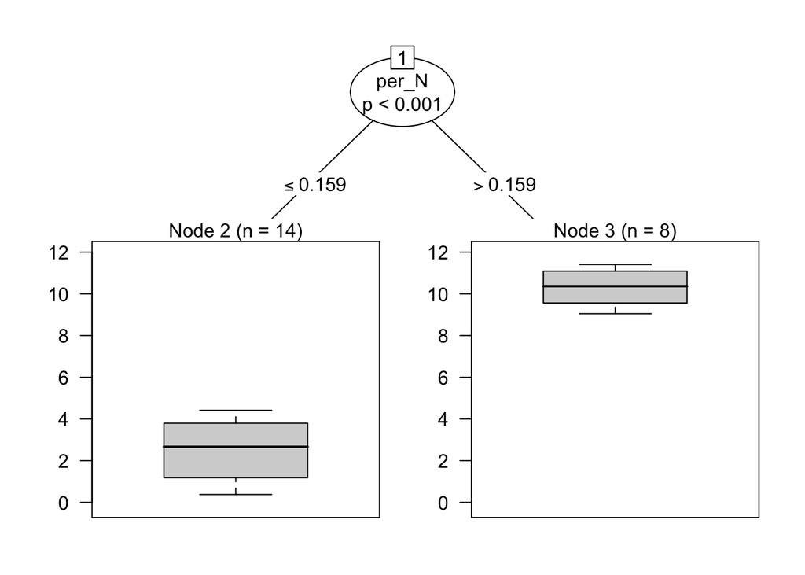

```r
ct1 <- ctree(yield ~ site + nitrogen + div_rich + div_shan + div_simp + ph + p_ppm + est_cec + per_N + per_C + cn_ratio, data = master)
plot(ct1)
```

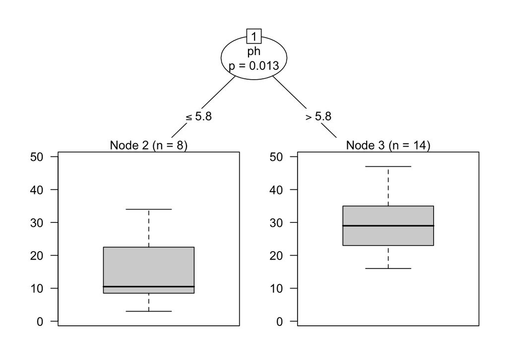

```r
ct2 <- ctree(div_rich ~ site + nitrogen + ph + p_ppm + est_cec + per_N + per_C + cn_ratio, data = master)
plot(ct2)
```

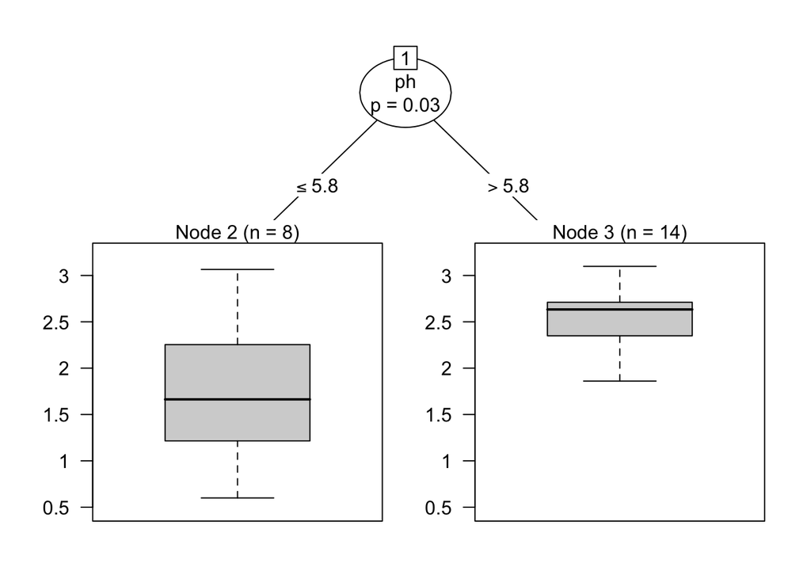

```r
ct3 <- ctree(div_shan ~ site + nitrogen + ph + p_ppm + est_cec + per_N + per_C + cn_ratio, data = master)
plot(ct3)
```

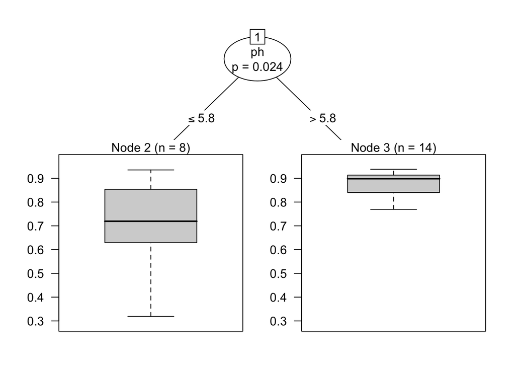

```r
ct4 <- ctree(div_simp ~ site + nitrogen + ph + p_ppm + est_cec + per_N + per_C + cn_ratio, data = master)
plot(ct4)
```

## Random Forest

```r
rf1 <- randomForest(yield ~ site + nitrogen + div_rich + div_shan + div_simp + ph + p_ppm + est_cec + per_N + per_C + cn_ratio, data = master)
print(rf1)
```

```
##
## Call:
##  randomForest(formula = yield ~ site + nitrogen + div_rich + div_shan +      div_simp + ph + p_ppm + est_cec + per_N + per_C + cn_ratio,      data = master)
##                Type of random forest: regression
##                      Number of trees: 500
## No. of variables tried at each split: 3
##
##           Mean of squared residuals: 1.116117
##                     % Var explained: 92.91
```

```r
importance(rf1)
```

```
##          IncNodePurity
## site         55.068507
## nitrogen      1.007995
## div_rich      5.726200
## div_shan      4.438614
## div_simp      3.667434
## ph            2.118766
## p_ppm        53.279427
## est_cec      54.145301
## per_N        69.903303
## per_C        23.111080
## cn_ratio     54.491764
```

```r
rf2 <- randomForest(div_rich ~ site + nitrogen + ph + p_ppm + est_cec + per_N + per_C + cn_ratio, data = master)
print(rf2)
```

```
##
## Call:
##  randomForest(formula = div_rich ~ site + nitrogen + ph + p_ppm +      est_cec + per_N + per_C + cn_ratio, data = master)
##                Type of random forest: regression
##                      Number of trees: 500
## No. of variables tried at each split: 2
##
##           Mean of squared residuals: 82.28729
##                     % Var explained: 40.39
```

```r
importance(rf2)
```

```
##          IncNodePurity
## site         355.64701
## nitrogen      39.01436
## ph           707.62738
## p_ppm        513.62968
## est_cec      302.73611
## per_N        233.72151
## per_C        221.02112
## cn_ratio     227.96243
```

```r
rf3 <- randomForest(div_shan ~ site + nitrogen + ph + p_ppm + est_cec + per_N + per_C + cn_ratio, data = master)
print(rf3)
```

```
##
## Call:
##  randomForest(formula = div_shan ~ site + nitrogen + ph + p_ppm +      est_cec + per_N + per_C + cn_ratio, data = master)
##                Type of random forest: regression
##                      Number of trees: 500
## No. of variables tried at each split: 2
##
##           Mean of squared residuals: 0.2207321
##                     % Var explained: 50.68
```

```r
importance(rf3)
```

```
##          IncNodePurity
## site         0.9521449
## nitrogen     0.1370231
## ph           2.4189107
## p_ppm        1.3962311
## est_cec      1.0794323
## per_N        1.0773652
## per_C        0.7019694
## cn_ratio     0.6874590
```

```r
rf4 <- randomForest(div_simp ~ site + nitrogen + ph + p_ppm + est_cec + per_N + per_C + cn_ratio, data = master)
print(rf4)
```

```
##
## Call:
##  randomForest(formula = div_simp ~ site + nitrogen + ph + p_ppm +      est_cec + per_N + per_C + cn_ratio, data = master)
##                Type of random forest: regression
##                      Number of trees: 500
## No. of variables tried at each split: 2
##
##           Mean of squared residuals: 0.01214362
##                     % Var explained: 40.93
```

```r
importance(rf4)
```

```
##          IncNodePurity
## site       0.039396302
## nitrogen   0.007178595
## ph         0.113997650
## p_ppm      0.058170123
## est_cec    0.027715401
## per_N      0.031474445
## per_C      0.036017599
## cn_ratio   0.040780349
```

## Linear Mixed Effects Regression Analysis

- Biomass differs significantly by site (p = 0.0002464) and by N treatment (p = 0.0209347). There is no interaction (p = 0.1395920). Biomass across the sites is as follows: Oregon > Rhinelander > Hancock, as we would expect given our knowledge of the soil fertility of each site. N amendment increases biomass.
- There is a significant site*nitrogen interaction for yield (p = 0.005733). Nitrogen amendment does not significantly affect yield at Hancock (p = 0.500882, B corrected p = 1.0) or Oregon (p = 0.071604, B corrected p = 0.214812) but it signiicantly increases it at Rhinelander (p = 0.002268, B corrected p = 0.006804).
- Plant height in September did not differ by site or nitrogen treatment and there was no interaction.
- Lodging frequency differed by site (p = 0.001885) with Oregon having a greater frequency of lodging than Rhinelander and Hancock.

```r
lmer_biomass <- lmer(biomass ~ site*nitrogen + (1|block:site), data = master, REML = FALSE); summary(lmer_biomass); anova(lmer_biomass); difflsmeans(lmer_biomass)
lmer_yield <- lmer(yield ~ site*nitrogen + (1|block:site), data = master); anova(lmer_yield); difflsmeans(lmer_yield)
lmer_height <- lmer(height ~ site*nitrogen + (1|block:site), data = master); anova(lmer_height); difflsmeans(lmer_height)
lmer_lodged <- lmer(lodged ~ site*nitrogen + (1|block:site), data = master); anova(lmer_lodged); difflsmeans(lmer_lodged)
```

- pH, percent C, percent N, C:N ratio, and cation exchange capacity differ significantly by site.
- There was actually a significant site by nitrogen interaction for phosphorus (p = 0.04241). Rhinelander and Oregon did not differ significantly with the addition of N, but Hancock did (p = 0.0214789). However, when corrected for multiple comparisons, this was no longer significant (p = 0.0644367).

```r
lmer_ph <- lmer(ph ~ site*nitrogen + (1|block:site), data = master); anova(lmer_ph); difflsmeans(lmer_ph)
lmer_p <- lmer(p_ppm ~ site*nitrogen + (1|block:site), data = master); anova(lmer_p); difflsmeans(lmer_p)
lmer_n <- lmer(per_N ~ site*nitrogen + (1|block:site), data = master); anova(lmer_n); difflsmeans(lmer_n)
lmer_c <- lmer(per_C ~ site*nitrogen + (1|block:site), data = master); anova(lmer_c); difflsmeans(lmer_c)
lmer_cn <- lmer(cn_ratio ~ site*nitrogen + (1|block:site), data = master); anova(lmer_cn); difflsmeans(lmer_cn)
lmer_cec <- lmer(est_cec ~ site*nitrogen + (1|block:site), data = master); anova(lmer_cec); difflsmeans(lmer_cec)
```

- rarefied richness and richness differ by site (p = 0.0107) as follows: Oregon and Hancock > Rhinelander.
- diveristy did not differ by site or N treatment.

```r
lmer_rar <- lmer(div_rar ~ site*nitrogen + (1|block:site), data = master); anova(lmer_rar); difflsmeans(lmer_rar)
plot(lmer_rar)
lmer_rich <- lmer(div_rich ~ site*nitrogen + (1|block:site), data = master); anova(lmer_rich); difflsmeans(lmer_rich)
plot(lmer_rich)
lmer_shan <- lmer(div_shan ~ site*nitrogen + (1|block:site), data = master); anova(lmer_shan); difflsmeans(lmer_shan)
plot(lmer_shan)
lmer_simp <- lmer(div_simp ~ site*nitrogen + (1|block:site), data = master); anova(lmer_simp); difflsmeans(lmer_simp)
plot(lmer_simp)
```

## Linear Mixed Effects Regression Analysis: Correlations

```r
lmer_biomass_null <- lmer(biomass ~ site*nitrogen + (1|block:site), data = master, REML = FALSE)
lmer_biomass_rich <- lmer(biomass ~ site*nitrogen + div_rich + (1|block:site), data = master, REML = FALSE); anova(lmer_biomass_null, lmer_biomass_rich)
lmer_biomass_rar <- lmer(biomass ~ site*nitrogen + div_rar + (1|block:site), data = master, REML = FALSE); anova(lmer_biomass_null, lmer_biomass_rar)
lmer_biomass_shan <- lmer(biomass ~ site*nitrogen + div_shan + (1|block:site), data = master, REML = FALSE); anova(lmer_biomass_null, lmer_biomass_shan)
lmer_biomass_simp <- lmer(biomass ~ site*nitrogen + div_simp + (1|block:site), data = master, REML = FALSE); anova(lmer_biomass_null, lmer_biomass_simp)
```

```r
lmer_yield_null <- lmer(yield ~ site*nitrogen + (1|block:site), data = master, REML = FALSE)
lmer_yield_rich <- lmer(yield ~ site*nitrogen + div_rich + (1|block:site), data = master, REML = FALSE); anova(lmer_yield_null, lmer_yield_rich)
anova(lmer_yield_rich)
lmer_yield_rar <- lmer(yield ~ site*nitrogen + div_rar + (1|block:site), data = master, REML = FALSE); anova(lmer_yield_null, lmer_yield_rar)
lmer_yield_shan <- lmer(yield ~ site*nitrogen + div_shan + (1|block:site), data = master, REML = FALSE); anova(lmer_yield_null, lmer_yield_shan)
lmer_yield_simp <- lmer(yield ~ site*nitrogen + div_simp + (1|block:site), data = master, REML = FALSE); anova(lmer_yield_null, lmer_yield_simp)
```

```r
lmer_height_null <- lmer(height ~ site*nitrogen + (1|block:site), data = master, REML = FALSE)
lmer_height_rich <- lmer(height ~ site*nitrogen + div_rich + (1|block:site), data = master, REML = FALSE); anova(lmer_height_null, lmer_height_rich)
lmer_height_rar <- lmer(height ~ site*nitrogen + div_rar + (1|block:site), data = master, REML = FALSE); anova(lmer_height_null, lmer_height_rar)
lmer_height_shan <- lmer(height ~ site*nitrogen + div_shan + (1|block:site), data = master, REML = FALSE); anova(lmer_height_null, lmer_height_shan)
lmer_height_simp <- lmer(height ~ site*nitrogen + div_simp + (1|block:site), data = master, REML = FALSE); anova(lmer_height_null, lmer_height_simp)
```

```r
lmer_lodged_null <- lmer(lodged ~ site*nitrogen + (1|block:site), data = master, REML = FALSE)
lmer_lodged_rich <- lmer(lodged ~ site*nitrogen + div_rich + (1|block:site), data = master, REML = FALSE); anova(lmer_lodged_null, lmer_lodged_rich)
lmer_lodged_rar <- lmer(lodged ~ site*nitrogen + div_rar + (1|block:site), data = master, REML = FALSE); anova(lmer_lodged_null, lmer_lodged_rar)
lmer_lodged_shan <- lmer(lodged ~ site*nitrogen + div_shan + (1|block:site), data = master, REML = FALSE); anova(lmer_lodged_null, lmer_lodged_shan)
lmer_lodged_simp <- lmer(lodged ~ site*nitrogen + div_simp + (1|block:site), data = master, REML = FALSE); anova(lmer_lodged_null, lmer_lodged_simp)
anova(lmer_lodged_simp)
```

## Negative Binomial Model Analysis

This analysis follows the [`phyloseq` tutorial](https://bioconductor.org/packages/devel/bioc/vignettes/phyloseq/inst/doc/phyloseq-mixture-models.html) by Paul J. McMurdie and Susan Holmes.

```r
info$nitrogen <- relevel(info$nitrogen, ref = "control")
physeq <- phyloseq(otu_table(asv, taxa_are_rows = FALSE), sample_data(info), refseq(fas), tax_table(tax))
```

```r
physeq <- prune_samples(sample_sums(physeq) > 500, physeq)
dseq <- phyloseq_to_deseq2(physeq, ~ nitrogen + site)
gm_mean <- function(x, na.rm = TRUE){
  exp(sum(log(x[x > 0]), na.rm = na.rm) / length(x))
}
geoMeans <- apply(counts(dseq), 1, gm_mean)
dseq_geo = estimateSizeFactors(dseq, geoMeans = geoMeans)
dseq_geo = DESeq(dseq_geo, fitType="local")
```

```r
res <- results(dseq_geo)
res <- res[order(res$padj, na.last = NA), ]
alpha <- 0.01
sigtab <- res[(res$padj < alpha), ]
sigtab <- cbind(as(sigtab, "data.frame"), as(tax_table(physeq)[rownames(sigtab), ], "matrix"))
```

```r
posigtab <- sigtab[sigtab[, "log2FoldChange"] > 0, ]
posigtab <- posigtab[, c("baseMean", "log2FoldChange", "lfcSE", "padj", "Order", "Family", "Genus")]
posigtab
```

```
##        baseMean log2FoldChange    lfcSE         padj          Order
## ASV_12 27.29010       22.25124 3.748559 1.460792e-08 Paraglomerales
## ASV_45 17.78572       21.99423 3.748680 1.939161e-08 Paraglomerales
## ASV_85 15.11499       20.69746 3.781924 1.723358e-07 Paraglomerales
##                 Family      Genus
## ASV_12 Paraglomeraceae Paraglomus
## ASV_45 Paraglomeraceae Paraglomus
## ASV_85 Paraglomeraceae Paraglomus
```

```r
negsigtab <- sigtab[sigtab[, "log2FoldChange"] < 0, ]
negsigtab <- negsigtab[, c("baseMean", "log2FoldChange", "lfcSE", "padj", "Order", "Family", "Genus")]
negsigtab
```

```
##           baseMean log2FoldChange    lfcSE         padj          Order
## ASV_14  147.766642      -30.00000 3.727168 2.921384e-14 Paraglomerales
## ASV_21  107.533422      -28.84183 3.769829 3.498068e-13 Paraglomerales
## ASV_9    97.504656      -27.14234 3.725374 3.730556e-12 Paraglomerales
## ASV_18   89.979094      -26.86851 3.725229 4.803967e-12 Paraglomerales
## ASV_124  23.777203      -25.27850 3.770027 1.408645e-10 Paraglomerales
## ASV_176   7.015541      -23.49408 3.734457 1.838072e-09     Glomerales
## ASV_38   59.461016      -17.48532 3.768748 1.222052e-05 Paraglomerales
## ASV_26   31.062441      -11.54232 3.816920 7.937559e-03 Paraglomerales
##                  Family      Genus
## ASV_14  Paraglomeraceae Paraglomus
## ASV_21  Paraglomeraceae Paraglomus
## ASV_9   Paraglomeraceae Paraglomus
## ASV_18  Paraglomeraceae Paraglomus
## ASV_124 Paraglomeraceae Paraglomus
## ASV_176     Glomeraceae  Dominikia
## ASV_38  Paraglomeraceae Paraglomus
## ASV_26  Paraglomeraceae Paraglomus
```

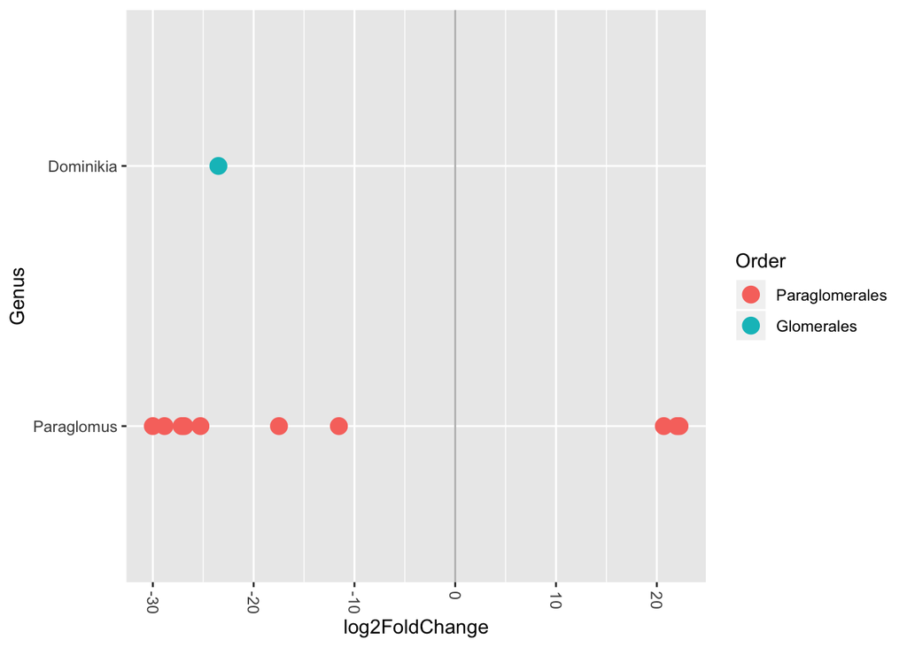

```r
sigtabgen <- subset(sigtab, !is.na(Genus))
# Order
x <- tapply(sigtabgen$log2FoldChange, sigtabgen$Order, function(x) max(x))
x <- sort(x, TRUE)
sigtabgen$Order <- factor(as.character(sigtabgen$Order), levels = names(x))
# Genus
x <- tapply(sigtabgen$log2FoldChange, sigtabgen$Genus, function(x) max(x))
x <- sort(x, TRUE)
sigtabgen$Genus = factor(as.character(sigtabgen$Genus), levels = names(x))
ggplot(sigtabgen, aes(y = Genus, x = log2FoldChange, color = Order)) +
  geom_vline(xintercept = 0.0, color = "gray", size = 0.5) +
  geom_point(size = 4) +
  theme(axis.text.x = element_text(angle = -90, hjust = 0, vjust = 0.5))
```

## Ordination

```r
# clean
physeq_trans <- transform_sample_counts(physeq, function(x) 1E6 * x/sum(x))
# plot ASVs
physeq_trans_ord <- ordinate(physeq_trans, "NMDS", "bray")
p1 <- plot_ordination(physeq_trans, physeq_trans_ord, type="taxa", color="Order", title="taxa")
print(p1)
# plot samples
p2 <- plot_ordination(physeq_filt_trans, physeq_filt_trans_ord, type="samples", color="site", title="Nirogen")
print(p2)
```

```r
# clean
physeq
```

```
## phyloseq-class experiment-level object
## otu_table()   OTU Table:         [ 412 taxa and 22 samples ]
## sample_data() Sample Data:       [ 22 samples by 27 sample variables ]
## tax_table()   Taxonomy Table:    [ 412 taxa by 7 taxonomic ranks ]
## refseq()      DNAStringSet:      [ 412 reference sequences ]
```

```r
filt <- genefilter_sample(physeq, filterfun_sample(function (x) x > 5))
physeq_filt <- prune_taxa(filt, physeq)
physeq_filt
```

```
## phyloseq-class experiment-level object
## otu_table()   OTU Table:         [ 386 taxa and 22 samples ]
## sample_data() Sample Data:       [ 22 samples by 27 sample variables ]
## tax_table()   Taxonomy Table:    [ 386 taxa by 7 taxonomic ranks ]
## refseq()      DNAStringSet:      [ 386 reference sequences ]
```

```r
physeq_filt_trans <- transform_sample_counts(physeq_filt, function(x) 1E6 * x/sum(x))
physeq_filt_trans
```

```
## phyloseq-class experiment-level object
## otu_table()   OTU Table:         [ 386 taxa and 22 samples ]
## sample_data() Sample Data:       [ 22 samples by 27 sample variables ]
## tax_table()   Taxonomy Table:    [ 386 taxa by 7 taxonomic ranks ]
## refseq()      DNAStringSet:      [ 386 reference sequences ]
```

```r
# plot ASVs
physeq_filt_trans_ord <- ordinate(physeq_filt_trans, "NMDS", "bray")
```

```
## Square root transformation
## Wisconsin double standardization
## *** No convergence -- monoMDS stopping criteria:
##     20: stress ratio > sratmax
```

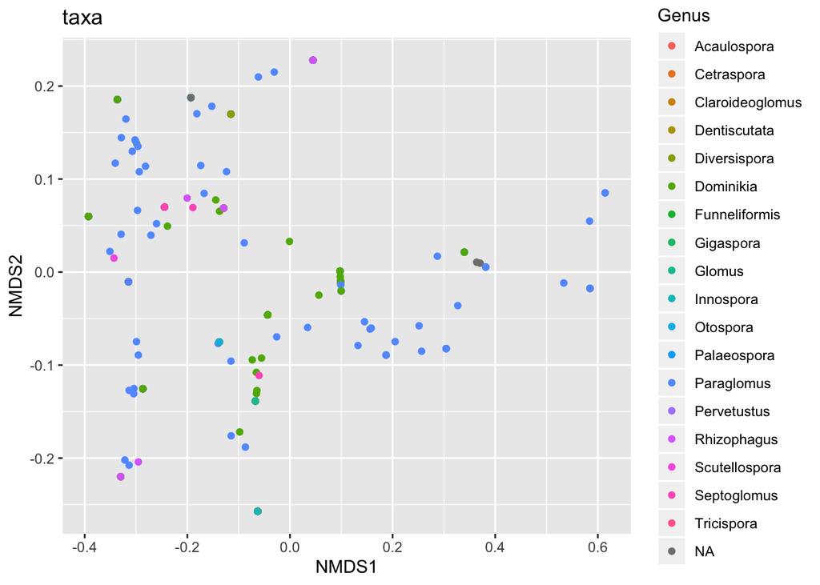

```r
p1 <- plot_ordination(physeq_filt_trans, physeq_filt_trans_ord, type="taxa", color="Genus", title="taxa")
print(p1)
```

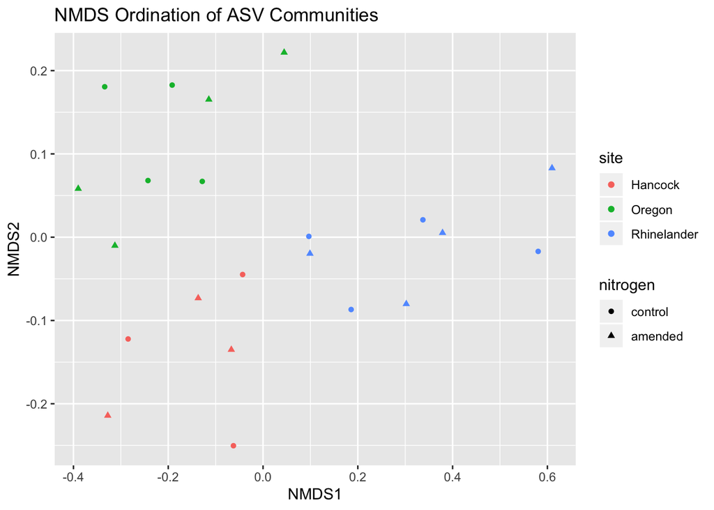

```r
# plot samples
p2 <- plot_ordination(physeq_filt_trans, physeq_filt_trans_ord, type="samples", color="site", title="NMDS Ordination of ASV Communities", shape = "nitrogen")
print(p2)
```

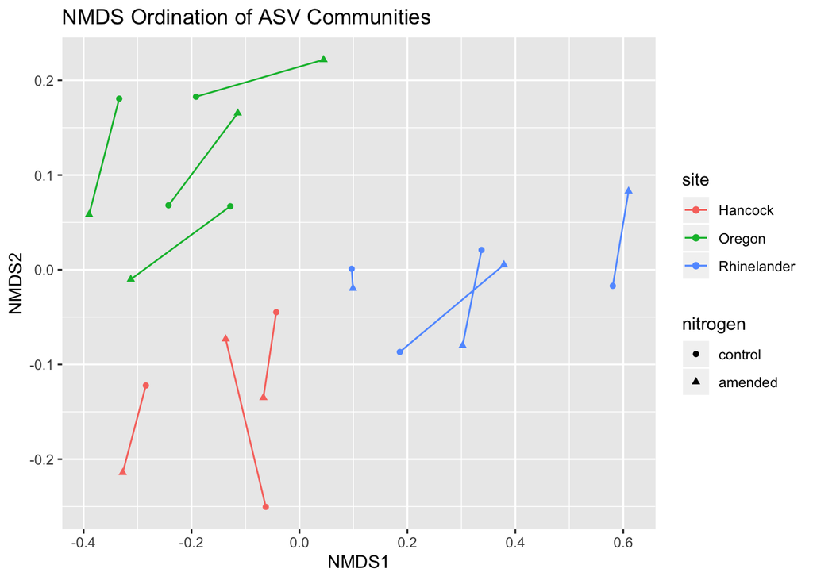

```r
p3 <- p2 + geom_line(aes(group = site:block))
print(p3)
```

```r
p3 <- plot_ordination(physeq_filt_trans, physeq_filt_trans_ord, type="biplot", color="site", shape="Family", title="biplot")
# Some stuff to modify the automatic shape scale
GP1.shape.names = get_taxa_unique(physeq_filt_trans, "Family")
GP1.shape <- 15:(15 + length(GP1.shape.names) - 1)
names(GP1.shape) <- GP1.shape.names
GP1.shape["samples"] <- 16
p3 + scale_shape_manual(values=GP1.shape)

p4 <- plot_ordination(physeq_filt_trans, physeq_filt_trans_ord, type="split", color="Family", shape="nitrogen", label="site", title="split")
p4
```